# Assignment 3: ECDF and Bootstrap Sampling and Applications

Sean Schilk

2/17/26

## **Question 1: Asymptotic vs Bootstrap Sampling Distributions**

The bootstrap sampling method simply generates random samples with replacement from a data set. These with replacement samples can act as new samples from the same population, with varying means and variation among them. This is useful because the true population can be seen as more with replacement samples are taken. The assumptions for Bootstrap are that the data set you are pulling from should be a good random sample from the target population, along with sticking with the same resample observation size as from the original data set. In addition, not only should you be drawing from a big enough sample in the first place, the observations themselves need to be i.i.d.. As I previously mentioned, the practical application would be capturing true population parameters, such as mean and variance, without access to the true population (which isn’t possible to know).

Now let’s look at a asymptotic sampling distribution. First let’s define it. It’s a probability distribution of statistics, such as mean or variance, as the number of observations approach infinity. Basically, we’ll know what proportion of the resulting sample mean will end up with as we take super large samples. The assumptions here are the observations are i.i.d. with a finite mean and finite variance. The practical application here of this distribution is that it helps us know when certain statistics, like a mean, will vary when we have a lot of data.

Resampling from the same sample, the Bootstrap method, would be most useful when dealing with a small dataset. If sampling cost is high, Bootstrap is preferred. However, with a large sample size, asymptotic would be more useful to get estimates.

## **Question 2: Daily Coffee Sales (in mL) at Two Different Cafe Locations**

1. Based on the given data, can the Central Limit Theorem be used to derive the asymptotic sampling distribution of the sample mean? Justify your answer.

Yes, as n>30, there is a finite mean and finite variance, and the observations are i.i.d.

2. Apply the bootstrap method to estimate the sampling distribution (often called the bootstrap sampling distribution) of the sample mean. Generate a kernel density estimate from the bootstrap sample means and plot it. Then, use this bootstrap distribution to validate your conclusion from part (a). Make sure your visuals are effective in enhancing the presentation of these results.

```r
data <- c(2850, 3200, 2900, 3100, 2950, 7800, 8100, 7900, 3300, 3050,
          4000, 4200, 3150, 3400, 7700, 8200, 3250, 4400, 3100, 4200,
          4500, 4800, 4300, 8500, 8200, 8900, 8700, 3250, 3000, 4600,
          4100, 8400, 8800, 3350, 4700, 3100, 8100, 3050, 8300, 4100,
          3100, 8300, 8900, 8200, 4400, 4500, 3250, 4600, 8400, 3300,
          4200, 4500, 4800, 4300, 8500)
mean(data)
```

```
[1] 5250
```

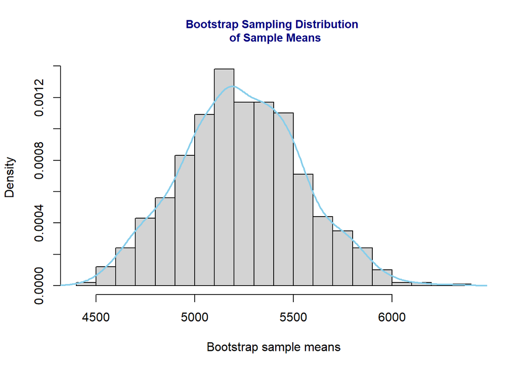

```r
bt.sample.mean.vec = NULL

for(i in 1:1000){
  ith.bt.sample = sample(x = data,
                    size = length(data),
                    replace = TRUE
                    )
bt.sample.mean.vec[i] = mean(ith.bt.sample)
}

hist(bt.sample.mean.vec,
     breaks = 14,
     probability = TRUE,
       xlab = "Bootstrap sample means",
        main="Bootstrap Sampling Distribution \n of Sample Means",
          cex.main = 0.9,
       col.main = "navy")
lines(density(bt.sample.mean.vec), col = "skyblue", lwd = 2)
```

As the histogram is approximately a bell curve, and roughly centered around the sample mean, my conclusion that the Central Limit Theorem be used to derive the asymptotic sampling distribution of the sample mean was correct.

3. Repeat the analysis in parts (a) and (b) for the sample variance.

CLT can apply for sample variance as well, as long as observations are i.i.d. with n>30

```r
var(data)
```

```
[1] 5030833
```

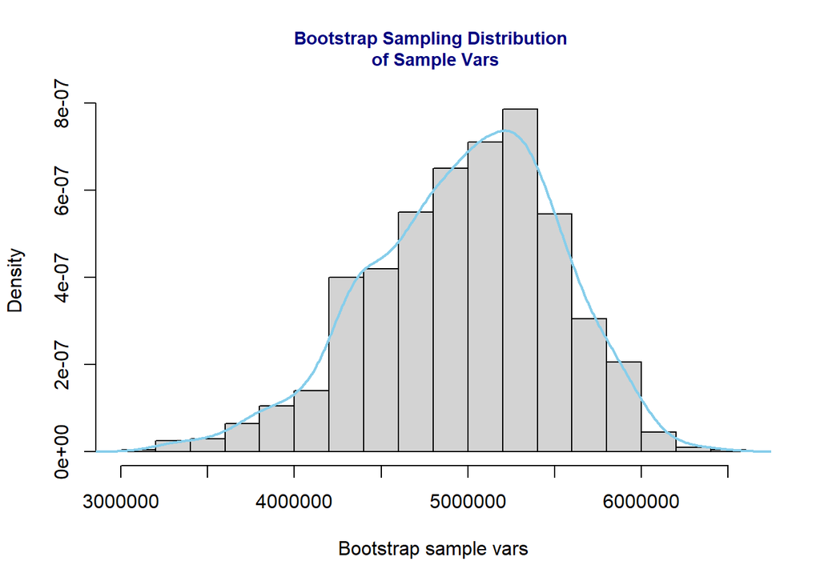

```r
bt.sample.var.vec = NULL

for(i in 1:1000){
  ith.bt.sample = sample(x = data,
                    size = length(data),
                    replace = TRUE
                    )
bt.sample.var.vec[i] = var(ith.bt.sample)
}

hist(bt.sample.var.vec,
     breaks = 14,
     probability = TRUE,
       xlab = "Bootstrap sample vars",
        main="Bootstrap Sampling Distribution \n of Sample Vars",
          cex.main = 0.9,
       col.main = "navy")
lines(density(bt.sample.var.vec), col = "skyblue", lwd = 2)
```

The histogram is approximately bell shaped again, with a slight left skew. However, it is still roughly centered around sample variance, so I will conclude the Central Limit Theorem approximation for the sample variance is reasonable.